# Make Sense of Deep Neural Networks using TensorBoard

github.com/PythonWorkshop/tensorboard_demos

## Arpan Chakraborty

@runoffthemill  
github.com/napratin

[figure not shown]

## Getting Started

*Note: This notebook is written in Python 3. You'll need Jupyter/iPython to run it.*

### Local installation

Fetch the repo: github.com/PythonWorkshop/tensorboard_demos

```
git clone git@github.com:PythonWorkshop/tensorboard_demos
cd tensorboard_demos/
```

#### Option A: Conda install

```
conda env create
source activate tensorflow
jupyter notebook tensorboard_basics.ipynb
```

#### Option B: Pip install

```
pip3 install numpy matplotlib scikit-learn
pip3 install --upgrade <binary URL for your system>
jupyter notebook tensorboard_basics.ipynb
```

See [TensorFlow instructions](https://www.tensorflow.org/versions/master/get_started/os_setup.html#pip-installation) to pick the correct binary URL for your system.

### Binder

[figure not shown]

If you have trouble getting TensorFlow to work, hit the **launch binder** badge to run in the cloud. Note that this is an experimental feature.

## Neural Networks Primer

A brief introduction to neural networks, with an eye on data structures.

### Simple linear model

Express output ($y$) as a linear combination of inputs ($x$):

$$\large{y = x_0 w_0 + x_1 w_1 + \ldots + x_n w_n + b}$$

Learning goal: Given enough examples of $x$ and $y$, find $w$ and $b$ that best capture the mapping.

### Linear model: Vector notation

$$\large{y = \begin{bmatrix}x_0 & x_1 & \ldots & x_n\end{bmatrix} \begin{bmatrix}w_0 \\ w_1 \\ \vdots \\ w_n\end{bmatrix} + b}$$

### Linear model: Graphical representation

[figure not shown]

## Single neuron model

[figure not shown]

### Neuron model: Vector notation

$$\large{y = f(\begin{bmatrix}x_0 & x_1 & \ldots & x_n\end{bmatrix} \begin{bmatrix}w_0 \\ w_1 \\ \vdots \\ w_n\end{bmatrix} + b)}$$

Here $f()$ is a *non-linear* activation function, that maps real-valued output $y$ to some target space, e.g. the sigmoid function maps to $[0, 1]$.

### Multiple neurons

Instead of a single neuron, now we have $m$ of them.

$$\begin{bmatrix}y_0 & y_1 & \ldots & y_m\end{bmatrix} = f(\begin{bmatrix}x_0 & x_1 & \ldots & x_n\end{bmatrix} \begin{bmatrix}w_{00} & w_{01} & \ldots & w_{0m} \\ w_{10} & w_{11} & \ldots & w_{1m} \\ \vdots & \vdots & \ddots & \vdots \\ w_{n0} & w_{n1} & \ldots & w_{nm} \end{bmatrix} + \begin{bmatrix}b_0 & b_1 & \ldots & b_m\end{bmatrix})$$

This is equivalent to a *layer* of neurons.

### Multiple neurons: Graphical representation

[figure not shown]

### Process multiple data samples at once

Instead of a single data sample, now we are dealing with $k$ samples in parallel.

$$\begin{bmatrix} y_{00} & y_{01} & \ldots & y_{0m} \\ y_{10} & y_{11} & \ldots & y_{1m} \\ \vdots & \vdots & \ddots & \vdots \\ y_{k0} & y_{k1} & \ldots & y_{km} \end{bmatrix} = f( \begin{bmatrix} x_{00} & x_{01} & \ldots & x_{0n} \\ x_{10} & x_{11} & \ldots & x_{1n} \\ \vdots & \vdots & \ddots & \vdots \\ x_{k0} & x_{k1} & \ldots & x_{kn} \end{bmatrix} \begin{bmatrix} w_{00} & w_{01} & \ldots & w_{0m} \\ w_{10} & w_{11} & \ldots & w_{1m} \\ \vdots & \vdots & \ddots & \vdots \\ w_{n0} & w_{n1} & \ldots & w_{nm} \end{bmatrix} + \begin{bmatrix}b_0 & b_1 & \ldots & b_m\end{bmatrix} )$$

*Note: Here the bias values $b$ are repeated for each sample (row).*

### What does this all look like?

# Tensors!

## Deep Neural Networks

[figure not shown]

### Ready for some Machine Learning?

## Generate Some Data to Classify

```python
import numpy as np

num_examples, num_features = (1000, 2)  # dataset size
num_classes = 2  # binary classification task

X = np.random.random((num_examples, num_features))
y = np.int_(X[:, 0] * X[:, 0] + X[:, 1] >= 1).reshape(-1, 1)
```

```python
print("Features (X): {shape[0]}x{shape[1]}".format(shape=X.shape))
print(X[:10])
```

```
Features (X): 1000x2
[[ 0.58131783  0.88220196]
 [ 0.32271971  0.66875673]
 [ 0.76230939  0.81780096]
 [ 0.74621405  0.98854818]
 [ 0.15623095  0.24135688]
 [ 0.66695772  0.01679651]
 [ 0.1366084   0.92259865]
 [ 0.76106016  0.01053627]
 [ 0.70015185  0.48760624]
 [ 0.86853786  0.193374  ]]
```

```python
print("Labels (y): {shape[0]}".format(shape=y.shape))
print(y[:10])
```

```
Labels (y): 1000
[[1]
 [0]
 [1]
 [1]
 [0]
 [0]
 [0]
 [0]
 [0]
 [0]]
```

## Visualize Data

```python
import matplotlib.pyplot as plt
%matplotlib inline
plt.style.use('ggplot')

def plot_data_2D(X, **kwargs):
    """Plot 2D data points in X = np.array([(x0, y0), (x1, y1), ...])."""
    fig, ax = plt.subplots(figsize=(9, 9))
    ax.scatter(X[:, 0], X[:, 1],
               s=35, cmap=plt.cm.get_cmap('rainbow', num_classes), **kwargs)
    ax.set_aspect('equal')
    ax.set_xlim(0, 1)
    ax.set_ylim(0, 1)
    return fig, ax
```

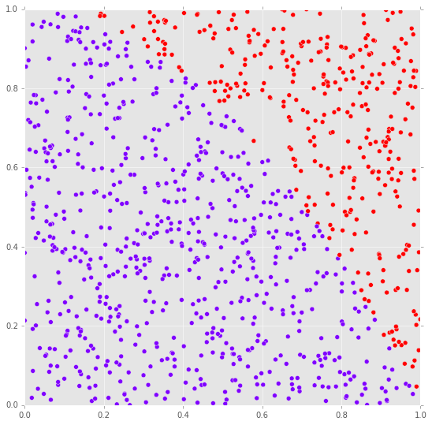

```python
plot_data_2D(X, c=y)
```

## Prepare Data for Training and Testing

```python
# Split data into training and test sets
from sklearn.cross_validation import train_test_split

test_size = 300
X_train, X_test, y_train, y_test = train_test_split(X, y, test_size=test_size)
print("Split dataset: {} training, {} test samples".format(len(X_train), len(X_test)))
```

```
Split dataset: 700 training, 300 test samples
```

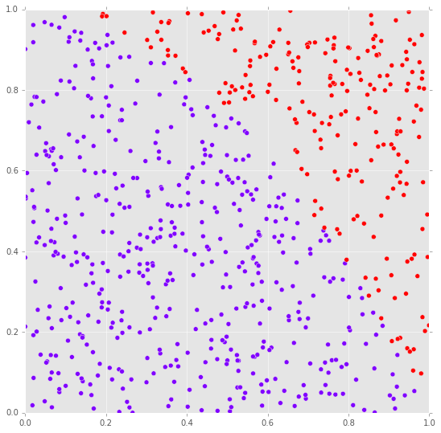

```python
# Plot training data
plot_data_2D(X_train, c=y_train)
```

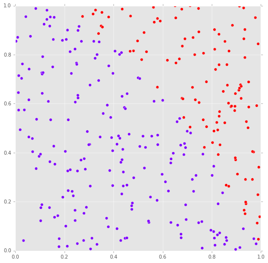

```python
# Plot test data
plot_data_2D(X_test, c=y_test)
```

## Build Computation Graph

This graph defines the structure of your Neural Network as well as information flow.

```python
import tensorflow as tf

# Create a TensorFlow session
session = tf.Session()

# Placeholders for input features and ground truth labels
X_placeholder = tf.placeholder(tf.float32,
                               shape=(None, num_features),
                               name="X")
y_placeholder = tf.placeholder(tf.int64,
                               shape=(None, 1),
                               name="y")
```

### Define helper functions

```python
def plot_activation(func, title, x_min=-10.0, x_max=10.0, num_samples=100):
    """Visualize a given activation function as a curve."""
    x = np.linspace(x_min, x_max, num_samples)
    fig, ax = plt.subplots(figsize=(8, 5))
    ax.plot(x, func(x), linewidth=3)
    ax.set_title(title)
    ax.patch.set_facecolor('white')
    ax.xaxis.set_ticks([])
    ax.yaxis.set_ticks([])
    ax.set_xlim(x_min - 1, x_max + 1)
    ax.set_ylim(-0.1, 1.1)
```

### Define layer creation functions

```python
def linear_layer(input_tensor, num_units):
    """Linear activation layer: output = inputs * weights + biases"""
    num_inputs = input_tensor.get_shape()[1].value  # inspect tensor size
    weights = tf.Variable(
        tf.truncated_normal([num_inputs, num_units], stddev=1.0),
        name='weights')
    biases = tf.Variable(
        tf.zeros([num_units]),
        name='biases')
    return tf.add(tf.matmul(input_tensor, weights, name='multiply'), biases,
                  name='add')
```

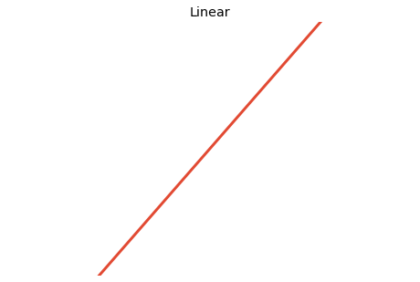

```python
plot_activation(lambda x: 0.5 + 0.1*x, title='Linear')  # example
```

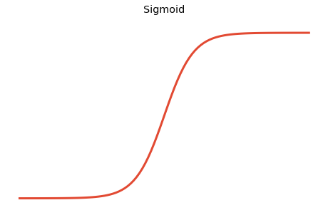

```python
def sigmoid_layer(input_tensor, num_units):
    """Sigmoid activation layer: output = sigmoid(inputs * weights + biases)"""
    return tf.nn.sigmoid(linear_layer(input_tensor, num_units), name='sigmoid')

plot_activation(lambda x: 1.0 / (1.0 + np.exp(-x)), title='Sigmoid')  # example
```

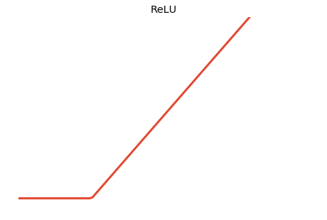

```python
def relu_layer(input_tensor, num_units):
    """ReLU activation layer: output = ReLU(inputs * weights + biases)"""
    return tf.nn.relu(linear_layer(input_tensor, num_units), name='relu')

plot_activation(lambda x: (0.5 + 0.1*x).clip(min=0), title='ReLU')  # example
```

### Create network structure

```python
# Let's make a network with 2 hidden layers (and an output layer)
hidden1_num_units = 10
hidden2_num_units = 3
output_num_units = 1  # binary classification needs only 1 output

with tf.name_scope('hidden1'):
    hidden1 = relu_layer(X_placeholder, hidden1_num_units)

with tf.name_scope('hidden2'):
    hidden2 = relu_layer(hidden1, hidden2_num_units)

with tf.name_scope('output'):
    output = sigmoid_layer(hidden2, output_num_units)
```

### Choose an error metric

```python
def l2_loss(logits, labels):
    """Euclidean distance or L2-norm: sqrt(sum((logits - labels)^2))"""
    labels = tf.to_float(labels)
    return tf.nn.l2_loss(logits - labels, name='l2_loss')

with tf.name_scope('error'):
    error = l2_loss(output, y_placeholder)  # predicted vs. true labels
    tf.scalar_summary(error.op.name, error)  # write error (loss) to log
```

```python
# Other possible error metrics
def mse_loss(logits, labels):
    """Mean squared error: mean(sum((logits - labels)^2)"""
    labels = tf.to_float(labels)
    return tf.reduce_mean(tf.square(logits - labels), name='mse_loss')

def cross_entropy_loss(logits, labels):
    """Mean cross-entropy loss: mean(cross_entropy(softmax(logits), labels))"""
    cross_entropy = tf.nn.sparse_softmax_cross_entropy_with_logits(logits, labels,
        name='cross_entropy')
    return tf.reduce_mean(cross_entropy, name='cross_entropy_mean')
```

```python
print("Nodes in computation graph:"
    + "\n  Input features: {}".format(X_placeholder)
    + "\n  Hidden layer 1: {}".format(hidden1)
    + "\n  Hidden layer 2: {}".format(hidden2)
    + "\n  Output labels : {}".format(output)
    + "\n  Ground truth  : {}".format(y_placeholder)
    + "\n  Error metric  : {}".format(error))
```

```
Nodes in computation graph:
  Input features: Tensor("X:0", shape=(?, 2), dtype=float32)
  Hidden layer 1: Tensor("hidden1/relu:0", shape=(?, 10), dtype=float32)
  Hidden layer 2: Tensor("hidden2/relu:0", shape=(?, 3), dtype=float32)
  Output labels : Tensor("output/sigmoid:0", shape=(?, 1), dtype=float32)
  Ground truth  : Tensor("y:0", shape=(?, 1), dtype=int64)
  Error metric  : Tensor("error/l2_loss:0", shape=(), dtype=float32)
```

## Setup Logging

These logs are later read and visualized by TensorBoard.

```python
import time
import os

log_basedir = "logs"
run_label = time.strftime('%Y-%m-%d_%H-%M-%S')  # e.g. 2016-08-18_21-30-45
log_path = os.path.join(log_basedir, run_label)
all_summaries = tf.merge_all_summaries()
summary_writer = tf.train.SummaryWriter(log_path, session.graph)
print("Logging to: {}".format(log_path))
```

```
Logging to: logs/2016-08-21_17-17-38
```

## Train your Model

```python
# Pick a training algorithm
def sgd_train(error, learning_rate=0.01):
    """Gradient descent optimizer for training.

    Creates an optimizer to compute and apply gradients to all trainable variables.

    Args:
        error: Error (loss) metric.
        learning_rate: Controls the size of each step the optimizer takes.
    Returns:
        training: Training operation, ready to be called with tf.Session.run().
    """
    optimizer = tf.train.GradientDescentOptimizer(learning_rate)
    return optimizer.minimize(error)

with tf.name_scope('training'):
    training = sgd_train(error)
```

```python
# Define training parameters
num_steps = 1000  # how many iterations to train for
batch_size = 100  # how many samples in each iteration

# Initialize variables
init_op = tf.initialize_all_variables()
session.run(init_op)
```

```python
# Run training operation for num_steps iterations
for step in range(num_steps):
    # Randomly pick batch_size samples from training set
    sample_idx = np.random.choice(len(X_train), batch_size, replace=False)
    feed_dict = {
        X_placeholder: X_train[sample_idx, :],
        y_placeholder: y_train[sample_idx, :]
    }
    # Note: feed_dict uses placeholder objects as key!

    # Train for one iteration, time it
    start_time = time.time()
    _, error_value = session.run([training, error], feed_dict=feed_dict)
    duration = time.time() - start_time

    # Print an overview and write summaries (logs) every 100 iterations
    if step % 100 == 0 or step == (num_steps - 1):
        print("Step {:4d}: training error = {:5.2f} ({:.3f} sec)"
            .format(step, error_value, duration))
        summary_str = session.run(all_summaries, feed_dict=feed_dict)
        summary_writer.add_summary(summary_str, step)
        summary_writer.flush()
```

```
Step    0: training error = 30.18 (0.022 sec)
Step  100: training error =  1.53 (0.002 sec)
Step  200: training error =  2.75 (0.002 sec)
Step  300: training error =  2.76 (0.002 sec)
Step  400: training error =  1.60 (0.003 sec)
Step  500: training error =  1.01 (0.003 sec)
Step  600: training error =  0.63 (0.003 sec)
Step  700: training error =  0.90 (0.003 sec)
Step  800: training error =  2.26 (0.003 sec)
Step  900: training error =  0.96 (0.003 sec)
Step  999: training error =  1.16 (0.001 sec)
```

## Test your Model

```python
# Check performance on test set
y_test_pred, test_error = session.run([output, error], feed_dict={
    X_placeholder: X_test,
    y_placeholder: y_test
})
# Note: The placeholder shapes must be compatible with the tensors being supplied!
```

```
Test error = 3.33 (8 mismatches)
```

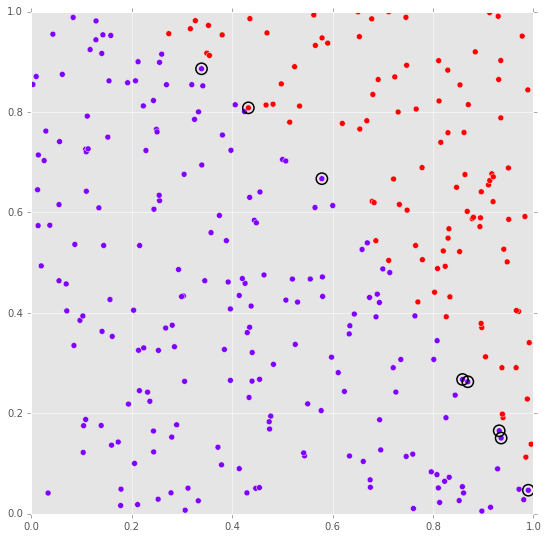

```python
y_test_pred = np.int_(np.round_(y_test_pred))
mismatches = (y_test_pred - y_test).flat != 0
print("Test error = {:.2f} ({} mismatches)"
      .format(test_error, sum(np.int_(mismatches))))

_, ax = plot_data_2D(X_test, c=y_test_pred)
ax.scatter(X_test[mismatches, 0], X_test[mismatches, 1],
           s=128, marker='o', facecolors='none', edgecolors='black', linewidths=1.5)
```

## Visualize using TensorBoard

Run TensorBoard with the following command, passing in the appropriate log directory:

```
tensorboard --logdir=logs
```

And then open the URL that gets printed, in your browser (typically: http://0.0.0.0:6006).

### Computation graph

[figure not shown]

### Layer detail: `hidden1`

[figure not shown]

### Error plot

[figure not shown]

## Summary

- Define a neural network model as nodes of a computation graph in TensorFlow.
- Train your model by presenting labeled data and applying an optimization algorithm.
- Log important values like error during training.
- Test your resulting model on unseen data.
- Visualize computation graph and logged data using TensorBoard.

**Note**: You can convert this notebook into slides (HTML + reveal.js) and serve them using:

```
jupyter nbconvert tensorboard_basics.ipynb --to slides --post serve
```

## References & Resources

This demo notebook is based on:

- [TensorBoard: Visualizing Learning](https://www.tensorflow.org/versions/master/how_tos/summaries_and_tensorboard/index.html)
- [TensorBoard: Graph Visualization](https://www.tensorflow.org/versions/master/how_tos/graph_viz/index.html)
- [MNIST Tutorial](https://github.com/tensorflow/tensorflow/tree/r0.8/tensorflow/examples/tutorials/mnist)

For more resources, check out:

- [SV Python Workshops meetup](http://www.meetup.com/SV-Python-Workshops): We host machine learning and data science meetups.
- [Udacity-Google Deep Learning course](https://www.udacity.com/course/deep-learning--ud730): Free course, uses TensorFlow for assignments.

# Make Sense of Deep Neural Networks using TensorBoard

github.com/PythonWorkshop/tensorboard_demos

## Arpan Chakraborty

@runoffthemill  
github.com/napratin

[figure not shown]